# Legislator Training and Legislative Effectiveness

Data Construction and Initial Modeling Results

Mackenzie Dobson

# 1 Overview

This document presents the construction of the analysis dataset and initial descriptive and modeling results examining the relationship between legislator training programs and legislative effectiveness. Legislative effectiveness is measured in three ways. First, I construct stage-specific success measures that capture the proportion of bills that successfully move from one stage of the legislative process to the next (e.g., committee → out of committee → passage → enactment). Second, I use a composite measure (`SLES`) that aggregates bill sponsorship and advancement into a single summary score. Finally, to complement both the composite SLES measure and the stage-specific outcomes, I construct an additional summary measure of legislative success: the proportion of introduced bills that pass the chamber (`s_success_chamber`). This variable captures overall legislative effectiveness *conditional on bill introduction*, providing a measure of success that is not driven by the volume of legislation a legislator sponsors. This measure is motivated by a key limitation of composite `SLES`. Because `SLES` incorporates bill sponsorship as a component, it rewards legislators who introduce a larger number of bills. However, training programs often emphasize a different model of effective lawmaking—one in which legislators are encouraged to be more selective, prioritizing higher-quality proposals with a greater likelihood of success. Legislators who adopt this strategy may appear less effective under the composite measure, even if their bills are more likely to advance through the legislative process. While the stage-specific success measures capture these dynamics at each point in the lawmaking process, they do so separately for each stage. The `s_success_chamber` variable provides a useful bridge between these approaches by summarizing overall success while still conditioning on legislative activity. In doing so, it offers a measure that is analogous to composite effectiveness but isolates the “quality” dimension of legislative behavior.

# 2 Key Takeaways

# 3 Data Preparation

## 3.1 Load Data

```r
load('/Users/mackenziedobson/Dropbox/Legislator Training/Data/1_csg_prep.RData')
```

## 3.2 Merge Covariates

```r
covariates <- sles %>%
  select(
    state, chamber, state_chamber, term, sles_id, sles_sponsor,
    party, in_majority, comm_chair, seniority,
    female, pred.race, vote_share, np_score,
    ideo_med_distance, Leader_speakerpres,
    Leader_majleader, Leader_minleader,
    chair_of, power_comm, squire_index
  )
```

```r
df_region <- df_region %>%
  left_join(covariates, by = c("sles_id", "state", "chamber", "term"))

df_toll <- df_toll %>%
  left_join(covariates, by = c("sles_id", "state", "chamber", "term"))

df_ell <- df_ell %>%
  left_join(covariates, by = c("sles_id", "state", "chamber", "term"))
```

# 4 Dependent Variables

This analysis examines multiple measures of legislative effectiveness derived from State Legislative Effectiveness Scores (`SLES)` and underlying bill progression data. These measures capture both overall effectiveness and the ability of legislators to advance legislation through successive stages of the policymaking process.

## 4.1 Composite Legislative Effectiveness

The primary dependent variable is the composite SLES score (`SLES`). This measure aggregates information on bill sponsorship and legislative success across stages into a single summary metric of effectiveness. Legislators receive higher scores when they sponsor more legislation and when their bills are more likely to advance through the legislative process.

To address potential selection into training—particularly the possibility that more effective or upward-trending legislators (i.e., “rising stars”) are more likely to participate—models include a lagged benchmark measure of effectiveness (`lag_SLES_ratio`). Benchmark scores are constructed by estimating a regression of legislative effectiveness on factors such as seniority, majority party status, and leadership positions, and then generating predicted values that capture expected effectiveness given a legislator’s institutional position (Volden and Wiseman 2014; Bucchianeri, Volden, and Wiseman 2025). The benchmark ratio reflects the extent to which a legislator over- or under-performs relative to this expectation. The lagged version of this measure is computed within legislator × chamber over time, ensuring that it reflects a true prior-term baseline. Including this lag helps account for pre-existing differences in legislative effectiveness and isolates changes associated with training programs.

## 4.2 Stage-Specific Success

To more precisely isolate where in the legislative process training may matter, we examine stage-specific success rates. These measures are constructed as *conditional transition probabilities*, capturing the proportion of bills that successfully move from one stage of the legislative process to the next.

For substantive legislation, I construct:

- `s_success_committee`: Proportion of introduced bills that are referred to committee
- `s_success_out_committee`: Proportion of committee-referred bills that advance out of committee
- `s_success_passage`: Proportion of bills reported out of committee that pass the chamber
- `s_success_enactment`: Proportion of passed bills that are enacted into law

Each measure is bounded between 0 and 1 and reflects success conditional on reaching the prior stage. This formulation allows us to isolate where in the legislative process legislators succeed or fail, rather than collapsing performance into a single aggregate measure.

### 4.2.1 Why Stage-Specific Outcomes?

Focusing on stage-specific outcomes provides several advantages over relying exclusively on composite effectiveness scores.

First, recent work shows that composite measures of effectiveness can mask patterns of minority party influence (Dobson 2026). In particular, in chambers with high majority-party security—where electoral competition is low—minority legislators may successfully advance legislation through early stages of the process even when their bills rarely become law. Because composite scores heavily weight later-stage success, these contributions are often obscured. Stage-specific measures allow us to recover these dynamics by identifying where in the process minority legislators are able to exert influence. This is especially important for evaluating interventions, such as training programs, that may affect early-stage legislative activity (e.g., agenda access, committee navigation) even if they do not immediately translate into final passage.

Second, stage-specific outcomes allow for more flexible modeling strategies. Because these measures are not mechanically normalized within state-chamber, they can be estimated using legislator and term fixed effects. This enables within-legislator comparisons over time and strengthens causal identification. By contrast, composite SLES scores are constructed through normalization procedures that already account for institutional variation. As a result, incorporating fixed effects can be problematic. For these models, we instead rely on legislator random effects (with term fixed effects), which allow us to account for unobserved heterogeneity while respecting the structure of the outcome variable.

## 4.3 Proportion of Introductions Passing Chamber

I construct an overall measure of legislative success conditional on bill introduction. This measure captures the proportion of bills that successfully move from introduction to chamber passage, summarizing effectiveness across the legislative process while holding constant legislative activity.

For substantive legislation, I construct:

`s_success_chamber`: Proportion of introduced bills that pass the chamber

This measure is bounded between 0 and 1 and reflects success conditional on bill introduction. Unlike the stage-specific measures, which isolate transitions between individual stages, this variable summarizes overall success across the legislative process. In doing so, it provides a measure of legislative effectiveness that is not driven by the volume of bills introduced, but instead reflects the success rate of a legislator’s bill portfolio.

# 5 Distribution of Outcome Variables

## 5.1 Legislative Effectiveness (SLES)

### 5.1.1 Regional Sample

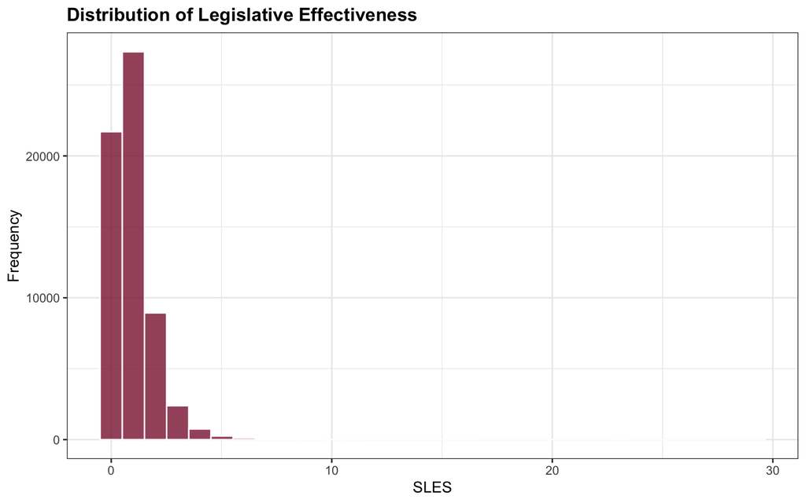

Summary Statistics: SLES (Regional Sample)

| variable | N | Mean | SD | Min | Q1 | Median | Q3 | Max | IQR |
| --- | --- | --- | --- | --- | --- | --- | --- | --- | --- |
| SLES | 61714 | 1 | 1.082 | 0 | 0.34 | 0.762 | 1.355 | 29.145 | 1.015 |

### 5.1.2 Toll Sample

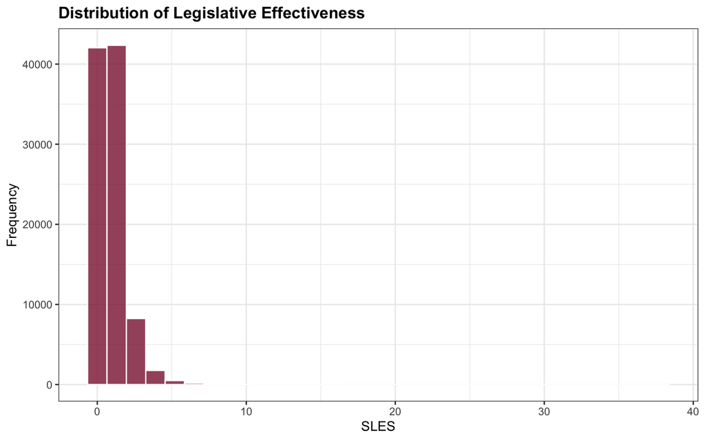

Summary Statistics: SLES (Toll Sample)

| variable | N | Mean | SD | Min | Q1 | Median | Q3 | Max | IQR |
| --- | --- | --- | --- | --- | --- | --- | --- | --- | --- |
| SLES | 95396 | 1 | 1.114 | 0 | 0.339 | 0.758 | 1.341 | 37.735 | 1.002 |

### 5.1.3 ELL Sample

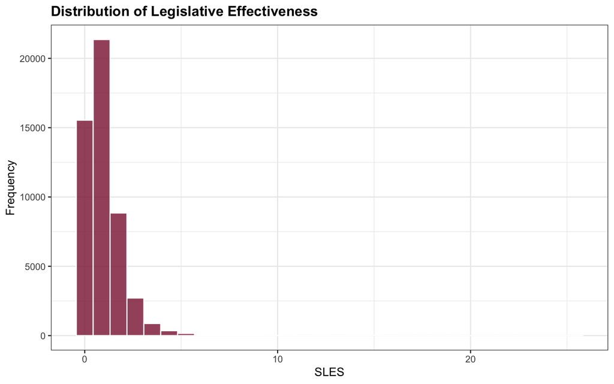

Summary Statistics: SLES (ELL Sample)

| variable | N | Mean | SD | Min | Q1 | Median | Q3 | Max | IQR |
| --- | --- | --- | --- | --- | --- | --- | --- | --- | --- |
| SLES | 50108 | 1 | 1.067 | 0 | 0.342 | 0.765 | 1.353 | 25.383 | 1.011 |

## 5.2 Stage-Specific Success Rates

### 5.2.1 Regional Sample

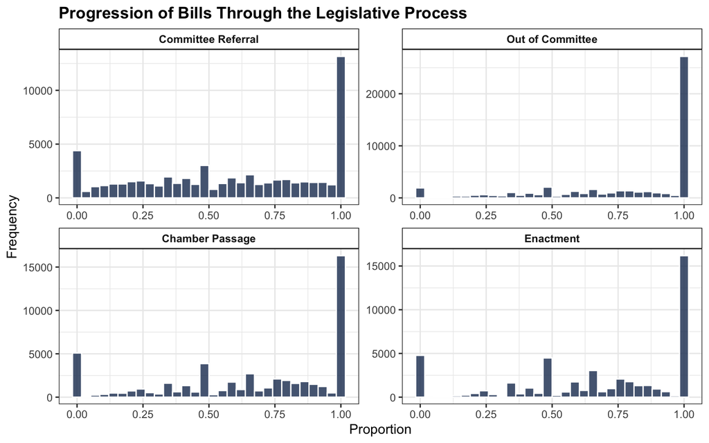

Stage-Specific Summary Statistics (Regional Sample)

| variable | N | Mean | SD | Min | Q1 | Median | Q3 | Max | IQR |
| --- | --- | --- | --- | --- | --- | --- | --- | --- | --- |
| Committee Referral | 58442 | 0.590 | 0.339 | 0 | 0.304 | 0.62 | 0.943 | 1 | 0.639 |
| Out of Committee | 51190 | 0.789 | 0.292 | 0 | 0.625 | 1.00 | 1.000 | 1 | 0.375 |
| Chamber Passage | 52403 | 0.665 | 0.334 | 0 | 0.444 | 0.75 | 1.000 | 1 | 0.556 |
| Enactment | 47334 | 0.679 | 0.326 | 0 | 0.500 | 0.75 | 1.000 | 1 | 0.500 |

### 5.2.2 Toll Sample

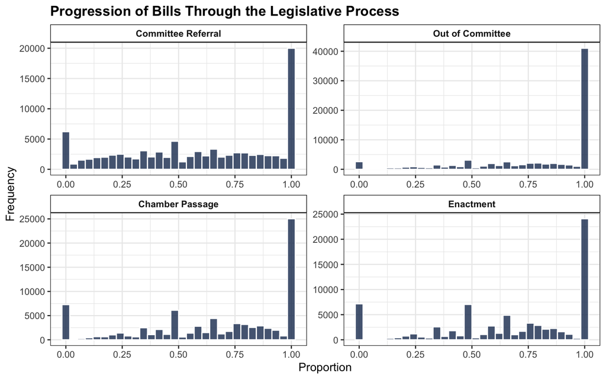

Stage-Specific Summary Statistics (Toll Sample)

| variable | N | Mean | SD | Min | Q1 | Median | Q3 | Max | IQR |
| --- | --- | --- | --- | --- | --- | --- | --- | --- | --- |
| Committee Referral | 90077 | 0.595 | 0.335 | 0 | 0.319 | 0.625 | 0.938 | 1 | 0.619 |
| Out of Committee | 77972 | 0.795 | 0.285 | 0 | 0.640 | 1.000 | 1.000 | 1 | 0.360 |
| Chamber Passage | 81787 | 0.672 | 0.325 | 0 | 0.489 | 0.750 | 1.000 | 1 | 0.511 |
| Enactment | 74544 | 0.674 | 0.323 | 0 | 0.500 | 0.750 | 1.000 | 1 | 0.500 |

### 5.2.3 ELL Sample

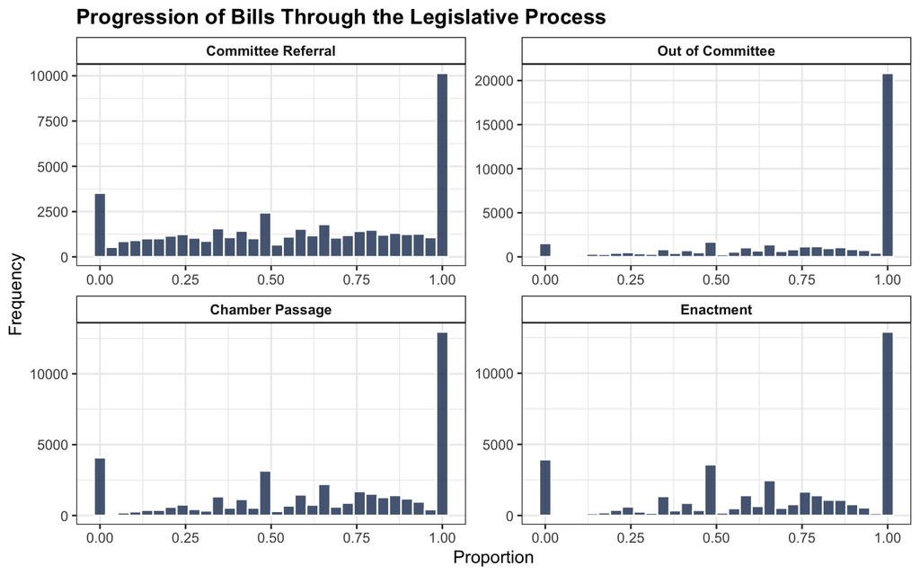

Stage-Specific Summary Statistics (ELL Sample)

| variable | N | Mean | SD | Min | Q1 | Median | Q3 | Max | IQR |
| --- | --- | --- | --- | --- | --- | --- | --- | --- | --- |
| Committee Referral | 47445 | 0.591 | 0.337 | 0 | 0.312 | 0.625 | 0.931 | 1 | 0.619 |
| Out of Committee | 41215 | 0.780 | 0.294 | 0 | 0.600 | 1.000 | 1.000 | 1 | 0.400 |
| Chamber Passage | 42626 | 0.660 | 0.333 | 0 | 0.440 | 0.750 | 1.000 | 1 | 0.560 |
| Enactment | 38563 | 0.674 | 0.328 | 0 | 0.500 | 0.750 | 1.000 | 1 | 0.500 |

## 5.3 Overall Success Conditional on Introduction

### 5.3.1 Regional Sample

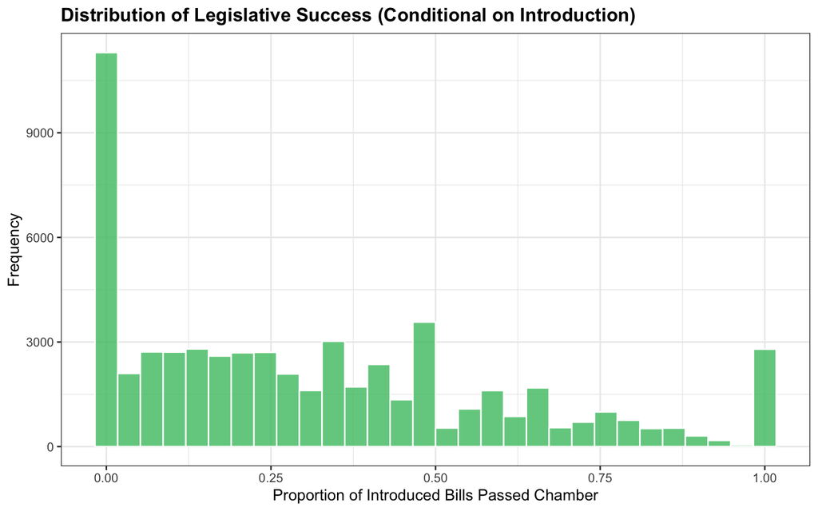

Summary Statistics: Proportion of Introduced Bills Passed (Regional Sample)

| variable | N | Mean | SD | Min | Q1 | Median | Q3 | Max | IQR |
| --- | --- | --- | --- | --- | --- | --- | --- | --- | --- |
| Proportion of Introduced Bills Passed | 58442 | 0.317 | 0.286 | 0 | 0.067 | 0.25 | 0.5 | 1 | 0.433 |

### 5.3.2 Toll Sample

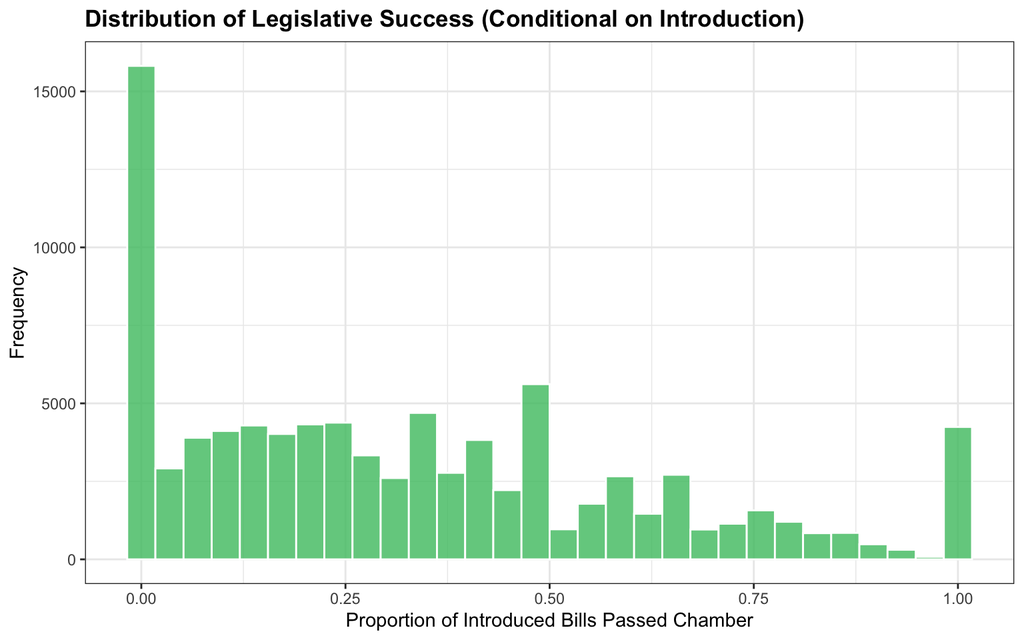

Summary Statistics: Proportion of Introduced Bills Passed (Toll Sample)

| variable | N | Mean | SD | Min | Q1 | Median | Q3 | Max | IQR |
| --- | --- | --- | --- | --- | --- | --- | --- | --- | --- |
| Proportion of Introduced Bills Passed | 90077 | 0.329 | 0.284 | 0 | 0.083 | 0.273 | 0.5 | 1 | 0.417 |

### 5.3.3 ELL Sample

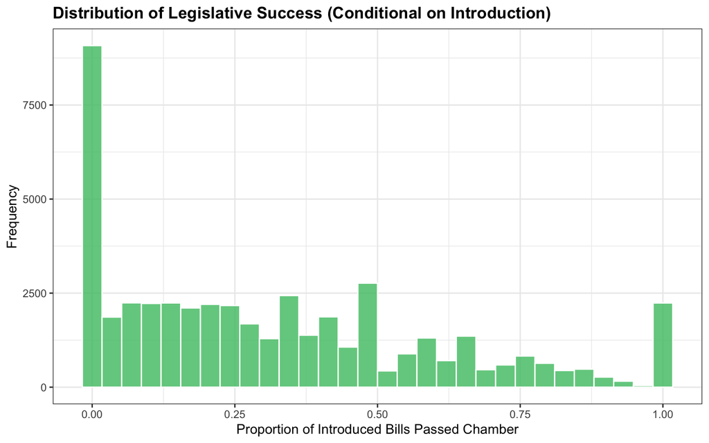

Summary Statistics: Proportion of Introduced Bills Passed (ELL Sample)

| variable | N | Mean | SD | Min | Q1 | Median | Q3 | Max | IQR |
| --- | --- | --- | --- | --- | --- | --- | --- | --- | --- |
| Proportion of Introduced Bills Passed | 47445 | 0.318 | 0.287 | 0 | 0.067 | 0.25 | 0.5 | 1 | 0.433 |

# 6 Modeling

## 6.1 Stage-specific Outcomes

To evaluate how legislative activity translates into advancement through the lawmaking process, I estimate stage-specific models where each dependent variable captures the proportion of bills that successfully move from one stage to the next (e.g., referral → out of committee → passage → enactment). These outcomes are conditional on reaching the prior stage, allowing us to isolate where in the process differences in effectiveness emerge.

All models are estimated using linear fixed effects specifications with chamber, legislator, and term fixed effects. Standard errors are two-way clustered by legislator and term. The dependent variables are standardized using `scale()` prior to estimation. As a result, coefficients can be interpreted as the change in legislative success (in standard deviations) associated with a one-unit increase in the predictor (e.g., moving from one to two terms of seniority). This makes effect sizes comparable across covariates and, importantly, across stages of the legislative process, which differ in their baseline distributions.

### 6.1.1 Regional Programs

```r
mod.region.committee <- felm(
  scale(s_success_committee) ~ treated + lag_SLES_ratio + seniority + in_majority +
    Leader_majleader + Leader_minleader + Leader_speakerpres + comm_chair + power_comm +
    ideo_med_distance + vote_share  |
    sles_id + state_chamber + term | 0 | sles_id + term,
  data = df_region
)

mod.region.out <- felm(
  scale(s_success_out_committee) ~ treated + lag_SLES_ratio + seniority + in_majority +
    Leader_majleader + Leader_minleader + Leader_speakerpres + comm_chair + power_comm +
    ideo_med_distance + vote_share  |
    sles_id + state_chamber + term | 0 | sles_id + term,
  data = df_region
)

mod.region.pass <- felm(
  scale(s_success_passage) ~ treated + lag_SLES_ratio + seniority + in_majority +
    Leader_majleader + Leader_minleader + Leader_speakerpres + comm_chair + power_comm +
    ideo_med_distance + vote_share  |
    sles_id + state_chamber + term | 0 | sles_id + term,
  data = df_region
)

mod.region.law <- felm(
  scale(s_success_enactment) ~ treated + lag_SLES_ratio + seniority + in_majority +
    Leader_majleader + Leader_minleader + Leader_speakerpres + comm_chair + power_comm +
    ideo_med_distance + vote_share  |
    sles_id + state_chamber + term | 0 | sles_id + term,
  data = df_region
)
```

Stage-Specific Standardized Legislative Success Models (Regional Sample)

|  | Committee | Out of Committee | Passage | Enactment |
| --- | --- | --- | --- | --- |
| Treated | −0.007 | 0.076 | −0.000 | −0.075 |
|  | (0.045) | (0.047) | (0.059) | (0.098) |
| SLES Benchmark (t-1) | −0.015* | −0.003 | −0.044*** | 0.001 |
|  | (0.008) | (0.005) | (0.008) | (0.010) |
| Seniority | −0.001 | −0.006 | 0.019** | 0.038*** |
|  | (0.006) | (0.007) | (0.008) | (0.012) |
| Majority Party | 0.404*** | 0.111* | 0.192*** | −0.011 |
|  | (0.045) | (0.056) | (0.053) | (0.048) |
| Majority Leadership | 0.044* | 0.083** | 0.053 | 0.028 |
|  | (0.025) | (0.034) | (0.037) | (0.045) |
| Minority Leadership | −0.005 | −0.015 | 0.110*** | 0.027 |
|  | (0.025) | (0.030) | (0.034) | (0.042) |
| Speaker/President | 0.047 | 0.068** | 0.053 | 0.029 |
|  | (0.030) | (0.024) | (0.034) | (0.038) |
| Committee Chair | 0.085*** | 0.038** | 0.024 | −0.032 |
|  | (0.014) | (0.016) | (0.019) | (0.027) |
| Power Committee | 0.025* | −0.032* | 0.042** | −0.020 |
|  | (0.014) | (0.016) | (0.016) | (0.023) |
| Distance from Median | −0.042 | −0.253*** | −0.060* | −0.010 |
|  | (0.035) | (0.067) | (0.032) | (0.044) |
| Vote Share | 0.014 | −0.005 | −0.005 | −0.062 |
|  | (0.029) | (0.053) | (0.054) | (0.045) |
| Observations | 27400 | 24061 | 24764 | 22529 |
| R² | 0.859 | 0.821 | 0.724 | 0.639 |
| Adjusted R² | 0.767 | 0.688 | 0.523 | 0.354 |

* p < 0.1, ** p < 0.05, *** p < 0.01  
*Note:* Standard errors in parentheses. All models include chamber, legislator, and term fixed effects. Standard errors are two-way clustered by legislator and term. Dependent variables are standardized using `scale()`; coefficients represent the change in legislative success (in standard deviations) associated with a one-unit change in each predictor, facilitating comparison of effect sizes across covariates.

### 6.1.2 Toll Program

```r
mod.toll.committee <- felm(
  scale(s_success_committee) ~ treated + lag_SLES_ratio + seniority + in_majority +
    Leader_majleader + Leader_minleader + Leader_speakerpres + comm_chair + power_comm +
    ideo_med_distance + vote_share  |
    sles_id + state_chamber + term | 0 | sles_id + term,
  data = df_toll
)

mod.toll.out <- felm(
  scale(s_success_out_committee) ~ treated + lag_SLES_ratio + seniority + in_majority +
    Leader_majleader + Leader_minleader + Leader_speakerpres + comm_chair + power_comm +
    ideo_med_distance + vote_share  |
    sles_id + state_chamber + term | 0 | sles_id + term,
  data = df_toll
)

mod.toll.pass <- felm(
  scale(s_success_passage) ~ treated + lag_SLES_ratio + seniority + in_majority +
    Leader_majleader + Leader_minleader + Leader_speakerpres + comm_chair + power_comm +
    ideo_med_distance + vote_share  |
    sles_id + state_chamber + term | 0 | sles_id + term,
  data = df_toll
)

mod.toll.law <- felm(
  scale(s_success_enactment) ~ treated + lag_SLES_ratio + seniority + in_majority +
    Leader_majleader + Leader_minleader + Leader_speakerpres + comm_chair + power_comm +
    ideo_med_distance + vote_share |
    sles_id + state_chamber + term | 0 | sles_id + term,
  data = df_toll
)
```

Stage-Specific Standardized Legislative Success Models (Toll Sample)

|  | Committee | Out of Committee | Passage | Enactment |
| --- | --- | --- | --- | --- |
| Treated | −0.042 | 0.066 | −0.060 | −0.045 |
|  | (0.047) | (0.058) | (0.070) | (0.084) |
| SLES Benchmark (t-1) | −0.005 | −0.007** | −0.022*** | 0.005 |
|  | (0.004) | (0.003) | (0.006) | (0.007) |
| Seniority | 0.007 | −0.004 | 0.015** | 0.018** |
|  | (0.004) | (0.005) | (0.006) | (0.008) |
| Majority Party | 0.288*** | 0.049 | 0.111*** | 0.002 |
|  | (0.031) | (0.030) | (0.036) | (0.041) |
| Majority Leadership | 0.054*** | 0.076*** | 0.018 | 0.036 |
|  | (0.020) | (0.024) | (0.026) | (0.028) |
| Minority Leadership | −0.047** | −0.008 | 0.051 | 0.046 |
|  | (0.019) | (0.020) | (0.032) | (0.033) |
| Speaker/President | 0.045 | 0.096*** | 0.061* | 0.025 |
|  | (0.027) | (0.019) | (0.032) | (0.025) |
| Committee Chair | 0.099*** | 0.053*** | 0.016 | −0.000 |
|  | (0.009) | (0.009) | (0.014) | (0.015) |
| Power Committee | 0.021** | −0.019* | 0.032** | 0.009 |
|  | (0.009) | (0.011) | (0.013) | (0.017) |
| Distance from Median | −0.070** | −0.215*** | −0.072** | 0.015 |
|  | (0.028) | (0.041) | (0.027) | (0.042) |
| Vote Share | 0.027 | 0.038 | 0.071** | −0.022 |
|  | (0.018) | (0.029) | (0.029) | (0.032) |
| Observations | 50493 | 43667 | 46324 | 42647 |
| R² | 0.834 | 0.796 | 0.668 | 0.581 |
| Adjusted R² | 0.757 | 0.688 | 0.500 | 0.356 |

* p < 0.1, ** p < 0.05, *** p < 0.01  
*Note:* Standard errors in parentheses. All models include chamber, legislator, and term fixed effects. Standard errors are two-way clustered by legislator and term. Dependent variables are standardized using `scale()`; coefficients represent the change in legislative success (in standard deviations) associated with a one-unit change in each predictor, facilitating comparison of effect sizes across covariates.

### 6.1.3 ELL Program

```r
mod.ell.committee <- felm(
  scale(s_success_committee) ~ treated + lag_SLES_ratio + seniority + in_majority +
    Leader_majleader + Leader_minleader + Leader_speakerpres + comm_chair + power_comm +
    ideo_med_distance + vote_share  |
    sles_id + state_chamber + term | 0 | sles_id + term,
  data = df_ell
)


mod.ell.out <- felm(
  scale(s_success_out_committee) ~ treated + lag_SLES_ratio + seniority + in_majority +
    Leader_majleader + Leader_minleader + Leader_speakerpres + comm_chair + power_comm +
    ideo_med_distance + vote_share  |
    sles_id + state_chamber + term | 0 | sles_id + term,
  data = df_ell
)

mod.ell.pass <- felm(
  scale(s_success_passage) ~ treated + lag_SLES_ratio + seniority + in_majority +
    Leader_majleader + Leader_minleader + Leader_speakerpres + comm_chair + power_comm +
    ideo_med_distance + vote_share  |
    sles_id + state_chamber + term | 0 | sles_id + term,
  data = df_ell
)

mod.ell.law <- felm(
  scale(s_success_enactment) ~ treated + lag_SLES_ratio + seniority + in_majority +
    Leader_majleader + Leader_minleader + Leader_speakerpres + comm_chair + power_comm +
    ideo_med_distance + vote_share  |
    sles_id + state_chamber + term | 0 | sles_id + term,
  data = df_ell
)
```

Stage-Specific Standardized Legislative Success Models (ELL Sample)

|  | Committee | Out of Committee | Passage | Enactment |
| --- | --- | --- | --- | --- |
| Treated | −0.004 | −0.151 | −0.130 | 0.179 |
|  | (0.095) | (0.089) | (0.108) | (0.154) |
| SLES Benchmark (t-1) | −0.037** | −0.011 | −0.047*** | −0.001 |
|  | (0.016) | (0.010) | (0.010) | (0.012) |
| Seniority | 0.005 | 0.006 | 0.015 | 0.024 |
|  | (0.008) | (0.014) | (0.011) | (0.017) |
| Majority Party | 0.316*** | 0.172*** | 0.169** | −0.057 |
|  | (0.057) | (0.050) | (0.069) | (0.080) |
| Majority Leadership | 0.051** | 0.041 | 0.089** | 0.071* |
|  | (0.022) | (0.039) | (0.036) | (0.037) |
| Minority Leadership | −0.028 | −0.028 | 0.099* | −0.017 |
|  | (0.028) | (0.031) | (0.051) | (0.052) |
| Speaker/President | 0.024 | 0.062 | 0.122* | 0.061 |
|  | (0.030) | (0.041) | (0.060) | (0.047) |
| Committee Chair | 0.073*** | 0.043** | 0.037 | 0.019 |
|  | (0.016) | (0.015) | (0.022) | (0.020) |
| Power Committee | 0.007 | −0.021 | 0.064*** | −0.006 |
|  | (0.019) | (0.014) | (0.018) | (0.021) |
| Distance from Median | 0.019 | −0.130** | −0.058 | −0.002 |
|  | (0.029) | (0.046) | (0.038) | (0.039) |
| Vote Share | 0.003 | 0.040 | 0.106** | −0.018 |
|  | (0.035) | (0.055) | (0.041) | (0.071) |
| Observations | 18660 | 16218 | 16924 | 15503 |
| R² | 0.881 | 0.865 | 0.784 | 0.716 |
| Adjusted R² | 0.776 | 0.732 | 0.578 | 0.428 |

* p < 0.1, ** p < 0.05, *** p < 0.01  
*Note:* Standard errors in parentheses. All models include chamber, legislator, and term fixed effects. Standard errors are two-way clustered by legislator and term. Dependent variables are standardized using `scale()`; coefficients represent the change in legislative success (in standard deviations) associated with a one-unit change in each predictor, facilitating comparison of effect sizes across covariates.

## 6.2 Composite SLES as an Outcome

As a complement to the stage-specific outcomes, I also estimate models using the composite `SLES` measure as the dependent variable. I present both fixed effects and random effects specifications. The fixed effects models include legislator and term fixed effects, isolating within-legislator changes in effectiveness over time. However, because SLES is already normalized within state-term, this approach absorbs a substantial amount of the available variation. To address this limitation, I also estimate random effects model with chamber and term fixed effects and legislator-level random intercepts. This specification accounts for unobserved heterogeneity across legislators while retaining cross-sectional variation in effectiveness.

### 6.2.1 Fixed Effects Specification

```r
mod.composite.fe.region <- felm(
  SLES ~ treated + lag_SLES_ratio + seniority + in_majority +
    Leader_majleader + Leader_minleader + Leader_speakerpres +
    comm_chair + power_comm + ideo_med_distance + vote_share  |
    sles_id + state_chamber + term | 0 | sles_id + term,
  data = df_region
)

mod.composite.fe.ell <- felm(
  SLES ~ treated + lag_SLES_ratio + seniority + in_majority +
    Leader_majleader + Leader_minleader + Leader_speakerpres +
    comm_chair + power_comm + ideo_med_distance + vote_share  |
    sles_id + state_chamber + term | 0 | sles_id + term,
  data = df_ell
)

mod.composite.fe.toll <- felm(
  SLES ~ treated + lag_SLES_ratio + seniority + in_majority +
    Leader_majleader + Leader_minleader + Leader_speakerpres +
    comm_chair + power_comm + ideo_med_distance + vote_share  |
    sles_id + state_chamber + term | 0 | sles_id + term,
  data = df_toll
)
```

Composite Legislative Effectiveness Models (SLES) – Fixed Effects

|  | Regional | ELL | Toll |
| --- | --- | --- | --- |
| Treated | 0.025 | 0.044 | −0.059 |
|  | (0.053) | (0.145) | (0.044) |
| SLES Benchmark (t-1) | 0.056 | −0.035 | 0.112*** |
|  | (0.046) | (0.085) | (0.036) |
| Seniority | 0.028** | 0.083*** | 0.029*** |
|  | (0.011) | (0.018) | (0.007) |
| Majority Party | 0.738*** | 0.662*** | 0.514*** |
|  | (0.055) | (0.077) | (0.058) |
| Majority Leadership | −0.074 | −0.030 | −0.022 |
|  | (0.044) | (0.050) | (0.031) |
| Minority Leadership | 0.027 | −0.031 | 0.006 |
|  | (0.052) | (0.049) | (0.025) |
| Speaker/President | 0.010 | 0.122 | 0.006 |
|  | (0.088) | (0.099) | (0.072) |
| Committee Chair | 0.269*** | 0.256*** | 0.393*** |
|  | (0.033) | (0.040) | (0.028) |
| Power Committee | 0.083*** | 0.112*** | 0.072*** |
|  | (0.023) | (0.018) | (0.016) |
| Distance from Median | −0.131** | −0.100 | −0.163*** |
|  | (0.047) | (0.055) | (0.052) |
| Vote Share | 0.044 | 0.094 | 0.052 |
|  | (0.053) | (0.069) | (0.041) |
| Observations | 28600 | 19506 | 52829 |

* p < 0.1, ** p < 0.05, *** p < 0.01  
Standard errors in parentheses. All models include chamber, legislator, and term fixed effects. Standard errors are two-way clustered by legislator and term.

### 6.2.2 Random Effects Specification

```r
mod.composite.re.region <- lmer(
  SLES~ treated + lag_SLES_ratio + seniority + in_majority + Leader_majleader +
    Leader_minleader + Leader_speakerpres + comm_chair + power_comm +
    ideo_med_distance + vote_share + factor(state_chamber) +
    factor(term) +
    (1 | sles_id),
  data = df_region
)

mod.composite.re.ell <- lmer(
  SLES ~ treated + lag_SLES_ratio + seniority + in_majority + Leader_majleader +
    Leader_minleader + Leader_speakerpres + comm_chair + power_comm +
    ideo_med_distance + vote_share + factor(state_chamber) +
    factor(term) +
    (1 | sles_id),
  data = df_ell
)

mod.composite.re.toll <- lmer(
  SLES ~ treated + lag_SLES_ratio + seniority + in_majority + Leader_majleader +
    Leader_minleader + Leader_speakerpres + comm_chair + power_comm +
    ideo_med_distance + vote_share + factor(state_chamber) +
    factor(term) +
    (1 | sles_id),
  data = df_toll
)
```

Composite Legislative Effectiveness Models (SLES) – Random Effects

|  | Regional | ELL | Toll |
| --- | --- | --- | --- |
| Treated | 0.093*** | 0.105* | −0.013 |
|  | (0.029) | (0.060) | (0.049) |
| SLES Benchmark (t-1) | 0.415*** | 0.438*** | 0.409*** |
|  | (0.006) | (0.007) | (0.005) |
| Seniority | 0.011*** | 0.015*** | 0.011*** |
|  | (0.002) | (0.003) | (0.002) |
| Majority Party | 0.569*** | 0.566*** | 0.488*** |
|  | (0.021) | (0.025) | (0.015) |
| Majority Leadership | −0.063** | −0.049 | −0.012 |
|  | (0.031) | (0.039) | (0.025) |
| Minority Leadership | 0.099*** | 0.047 | 0.055** |
|  | (0.030) | (0.040) | (0.025) |
| Speaker/President | 0.076** | 0.105** | 0.091*** |
|  | (0.034) | (0.041) | (0.027) |
| Committee Chair | 0.344*** | 0.333*** | 0.432*** |
|  | (0.015) | (0.017) | (0.011) |
| Power Committee | 0.065*** | 0.079*** | 0.080*** |
|  | (0.013) | (0.015) | (0.010) |
| Distance from Median | −0.089*** | −0.059*** | −0.086*** |
|  | (0.017) | (0.018) | (0.013) |
| Vote Share | 0.004 | 0.014 | 0.013 |
|  | (0.034) | (0.039) | (0.025) |
| Observations | 28600 | 19506 | 52829 |

* p < 0.1, ** p < 0.05, *** p < 0.01  
Standard errors in parentheses. Models include chamber and term fixed effects and legislator random intercepts.

## 6.3 Success Conditional on Introduction as an Outcome

As a complement to both the stage-specific outcomes and the composite `SLES` measure, I estimate models using the proportion of introduced bills that pass the chamber (`s_success_chamber`) as the dependent variable. This measure captures overall legislative success conditional on bill introduction, providing a summary measure of effectiveness that reflects the quality of a legislator’s bill portfolio rather than the volume of bills introduced. All models are estimated using linear fixed effects specifications with chamber, legislator, and term fixed effects, allowing for within-legislator comparisons over time. Standard errors are two-way clustered by legislator and term. The dependent variable is standardized using `scale()` prior to estimation, so coefficients can be interpreted as the change in legislative success (in standard deviations) associated with a one-unit change in each predictor. This facilitates comparison of effect sizes across covariates and aligns interpretation with the stage-specific models.

```r
mod.chamber.fe.region <- felm(
  scale(s_success_chamber) ~ treated + lag_SLES_ratio + seniority + in_majority +
    Leader_majleader + Leader_minleader + Leader_speakerpres +
    comm_chair + power_comm + ideo_med_distance + vote_share  |
    sles_id + state_chamber + term | 0 | sles_id + term,
  data = df_region
)

mod.chamber.fe.ell <- felm(
  scale(s_success_chamber) ~ treated + lag_SLES_ratio + seniority + in_majority +
    Leader_majleader + Leader_minleader + Leader_speakerpres +
    comm_chair + power_comm + ideo_med_distance + vote_share  |
    sles_id + state_chamber + term | 0 | sles_id + term,
  data = df_ell
)

mod.chamber.fe.toll <- felm(
  scale(s_success_chamber) ~ treated + lag_SLES_ratio + seniority + in_majority +
    Leader_majleader + Leader_minleader + Leader_speakerpres +
    comm_chair + power_comm + ideo_med_distance + vote_share  |
    sles_id + state_chamber + term | 0 | sles_id + term,
  data = df_toll
)
```

Legislative Success Conditional on Introduction (Fixed Effects)

|  | Regional | ELL | Toll |
| --- | --- | --- | --- |
| Treated | 0.011 | −0.224* | −0.023 |
|  | (0.041) | (0.104) | (0.048) |
| SLES Benchmark (t-1) | −0.045*** | −0.063*** | −0.023*** |
|  | (0.007) | (0.019) | (0.005) |
| Seniority | 0.011 | 0.024 | 0.014** |
|  | (0.008) | (0.014) | (0.006) |
| Majority Party | 0.361*** | 0.322*** | 0.254*** |
|  | (0.052) | (0.064) | (0.029) |
| Majority Leadership | 0.111*** | 0.156*** | 0.081*** |
|  | (0.029) | (0.042) | (0.026) |
| Minority Leadership | 0.007 | −0.013 | −0.052** |
|  | (0.031) | (0.034) | (0.023) |
| Speaker/President | 0.121*** | 0.129** | 0.129*** |
|  | (0.032) | (0.054) | (0.028) |
| Committee Chair | 0.096*** | 0.092*** | 0.106*** |
|  | (0.014) | (0.020) | (0.010) |
| Power Committee | 0.020* | 0.024 | 0.021** |
|  | (0.010) | (0.018) | (0.010) |
| Distance from Median | −0.143*** | −0.052* | −0.158*** |
|  | (0.038) | (0.023) | (0.029) |
| Vote Share | 0.026 | 0.061 | 0.056* |
|  | (0.045) | (0.049) | (0.031) |
| Observations | 27400 | 18660 | 50493 |

* p < 0.1, ** p < 0.05, *** p < 0.01  
Standard errors in parentheses. All models include chamber, legislator, and term fixed effects. Standard errors are two-way clustered by legislator and term. The dependent variable is standardized using `scale()`, so coefficients represent changes in legislative success (in standard deviations).